# TASK 3.3 多元统计分析

郝建锋

2017年11月19日

## 任务1：载入数据

```r
# 载入数据
mydata <- read.csv("D:/Desktop/TASK 3.3/data.csv")
summary(mydata)    # 检查数据
```

```
##     行驶里程         行驶时长          平均时速       时速标准差
##  Min.   :  0.04   Min.   :0.05056   Min.   : 0.70   Min.   : 2.088
##  1st Qu.:  1.00   1st Qu.:0.15326   1st Qu.:14.03   1st Qu.:11.987
##  Median :  3.00   Median :0.29264   Median :20.40   Median :16.496
##  Mean   : 12.17   Mean   :0.48330   Mean   :24.01   Mean   :18.058
##  3rd Qu.: 14.00   3rd Qu.:0.58257   3rd Qu.:31.83   3rd Qu.:23.438
##  Max.   :301.00   Max.   :3.66944   Max.   :90.22   Max.   :47.444
##    时速最大值         平稳性          转速平均值       转速标准差
##  Min.   :  6.00   Min.   :0.02432   Min.   : 746.4   Min.   : 84.16
##  1st Qu.: 43.00   1st Qu.:0.94901   1st Qu.:1057.5   1st Qu.:285.19
##  Median : 59.50   Median :1.05037   Median :1183.3   Median :367.32
##  Mean   : 63.96   Mean   :1.02643   Mean   :1224.7   Mean   :375.59
##  3rd Qu.: 82.00   3rd Qu.:1.13851   3rd Qu.:1356.6   3rd Qu.:457.03
##  Max.   :177.00   Max.   :1.47343   Max.   :2462.3   Max.   :890.78
##    转速最大值      早晚高峰         深夜出行          极度拥堵
##  Min.   : 982   Min.   :0.0000   Min.   :0.00000   Min.   :0.02439
##  1st Qu.:1790   1st Qu.:0.0000   1st Qu.:0.00000   1st Qu.:0.26104
##  Median :2117   Median :0.0000   Median :0.00000   Median :0.37893
##  Mean   :2176   Mean   :0.3451   Mean   :0.05001   Mean   :0.40231
##  3rd Qu.:2441   3rd Qu.:1.0000   3rd Qu.:0.00000   3rd Qu.:0.53182
##  Max.   :5411   Max.   :1.0000   Max.   :1.00000   Max.   :1.00000
##     高速行驶          疲劳驾驶            车号
##  Min.   :0.00000   Min.   :0.00000   Min.   :1.000
##  1st Qu.:0.00000   1st Qu.:0.00000   1st Qu.:3.000
##  Median :0.00000   Median :0.00000   Median :5.000
##  Mean   :0.01709   Mean   :0.09008   Mean   :4.676
##  3rd Qu.:0.00000   3rd Qu.:0.00000   3rd Qu.:6.000
##  Max.   :0.61943   Max.   :3.66944   Max.   :8.000
```

- 时间维度（行驶时长、疲劳驾驶、早晚高峰、深夜出行）;
- 速度维度（平均时速、最大时速、速度标准差、极度拥堵、高速驾驶）;
- 机械性能（平均引擎转速、最大引擎转速、转速标准差）;
- 里程维度（行驶里程）;
- 平稳性  
  下面本文借助箱线图对比每辆车的行驶里程数以及平均时速。

## 任务2：箱线图分析

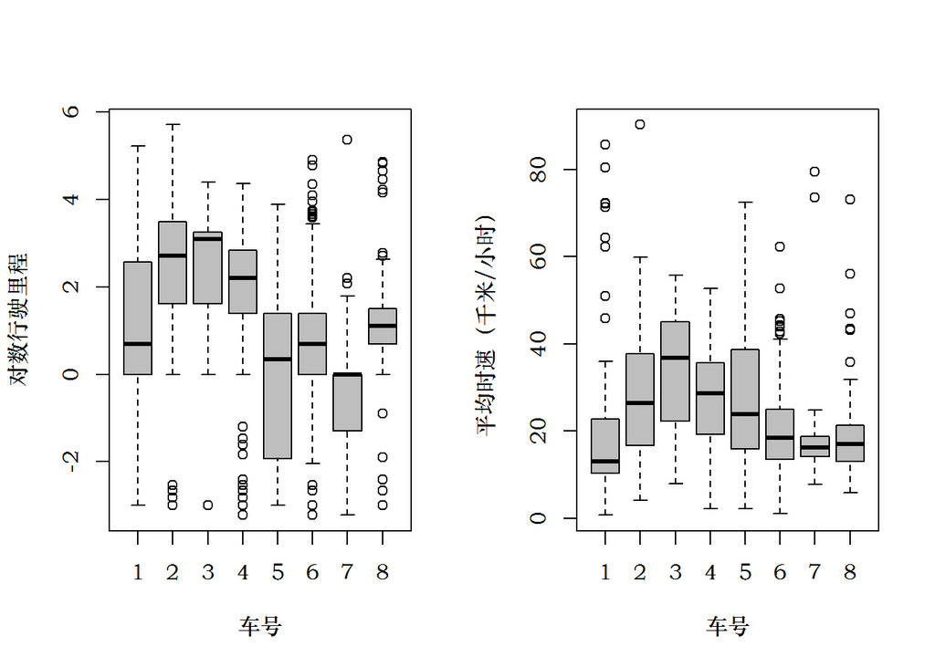

```r
library(ggplot2)                           # 载入可视化包
windowsFonts( A=windowsFont("华文中宋") )  # 设置系统字体

op<-par(no.readonly=TRUE)                  # 保存默认设置
par(mfrow=c(1,2),family="A")               # 设置画布
# 绘制每段路程的对数行驶里程箱线图
boxplot(log(行驶里程)~factor(车号), data=mydata,
        xlab="车号",ylab="对数行驶里程",
        col="grey")
# 绘制每段路程的平均时速箱线图
boxplot(平均时速~factor(车号), data=mydata,
        xlab="车号", ylab="平均时速（千米/小时）",
        col="grey")
```

从上图可以看出，以1号和3号车为例（也就是每组图的第1个和第3个箱子）：

- 1号车的平均行驶里程比3号车更短；
- 1号车的行驶里程的分布在一定程度上（箱子宽度）更加分散；
- 3号车的平均时速的平均水平（以中位数计）比1号车更高；
- 3号车的平均时速的分布在一定程度上（箱子宽度）比3号车更加分散。

## 任务3：因子分析I

```r
library(psych)            # 载入因子分析包
library(mvstats)          # 为利用factpc函数，得到因子分析的结果
pc_4 <- factpc(mydata[,-15], m=4, rotation="varimax")
```

```
##
##  Factor Analysis for Princomp in Varimax:
```

```
##          Vars Vars.Prop Vars.Cum
## Factor1 3.680    26.286    26.29
## Factor2 3.301    23.582    49.87
## Factor3 2.474    17.671    67.54
## Factor4 1.236     8.828    76.37
```

```
##            Factor1 Factor2 Factor3 Factor4
## 行驶里程     0.394   0.829   0.181   0.048 0.878
## 行驶时长     0.192   0.847   0.289   0.041 0.839
## 平均时速     0.873   0.362   0.226   0.118 0.958
## 时速标准差   0.677   0.392   0.482   0.063 0.849
## 时速最大值   0.653   0.420   0.504   0.047 0.859
## 平稳性       0.473   0.263   0.201  -0.097 0.343
## 转速平均值   0.711   0.178   0.509   0.185 0.830
## 转速标准差   0.273   0.153   0.864   0.092 0.853
## 转速最大值   0.240   0.215   0.858   0.077 0.845
## 早晚高峰    -0.014  -0.092  -0.045  -0.761 0.590
## 深夜出行     0.121  -0.041   0.084   0.746 0.579
## 极度拥堵    -0.886   0.008  -0.094  -0.132 0.811
## 高速行驶     0.424   0.712   0.037  -0.011 0.688
## 疲劳驾驶    -0.015   0.865   0.138   0.038 0.769
```

保留四个公因子的结果如上所示： 模型的累积方差贡献率为76.37%，比较优良，能解释大部分变量。 从四个公因子与14个初始变量的系数关系，本文为这四个公因子命名以及各个因子包含指标分别为：

- **Factor1：行驶速度**（平均时速、时速标准差、时速最大值、转速平均值、极度拥堵、平稳性），该因子得分高说明行驶速度大且较为平稳
- **Factor2：驾驶强度**（行驶里程、行驶时长、高速行驶、疲劳驾驶），该因子得分高说明驾驶时间长且路程远，疲劳驾驶可能性大
- **Factor3：引擎情况**（转速标准差、转速最大值），该因子得分高说明引擎转速高
- **Factor4：出行时间**（早晚高峰、深夜出行），该因子得分高说明是深夜出行、非早晚高峰。

```r
# 提取公因子得分情况
scores <- as.data.frame(pc_4$scores)
names(scores) <- c("行驶速度","驾驶强度","引擎情况","出行时间")
```

## 任务4：因子分析II

```r
fa.parallel(mydata[,-15], fa="pc", n.iter=100,
            show.legend = F)
```

```
## Parallel analysis suggests that the number of factors =  NA  and the number of components =  2
```

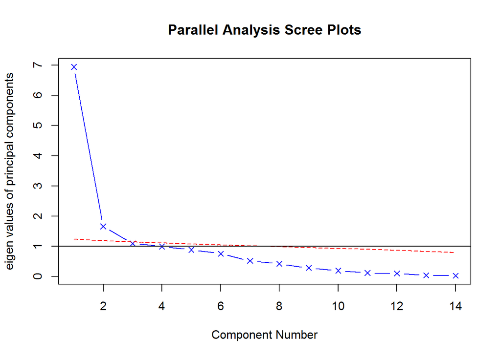

```r
abline(h=1)
```